# Codebook

**Authors:** Lauren Baker  
Documenting existing data files of DaanMatch with information about location, owner, "version", source etc.

```python
import boto3
import numpy as np
import pandas as pd
pd.plotting.register_matplotlib_converters()
import matplotlib.pyplot as plt
%matplotlib inline
from collections import Counter
import statistics
```

```python
client = boto3.client('s3')
resource = boto3.resource('s3')
my_bucket = resource.Bucket('daanmatchdatafiles')
```

# Daman_and_Diu_2016.xlsx

## TOC:

- About this dataset
- What's in this dataset
- Codebook
  - Missing values
  - Summary statistics
- Columns
  - CIN
  - COMPANY_NAME
  - COMPANY_CLASS
  - COMPANY_CATEGORY
  - COMPANY_SUBCAT
  - COMPANY_STATUS
  - DATE_OF_REGISTRATION
  - REGISTERED_STATE
  - Authorized Capital (Rs.)
  - PAIDUP_CAPITAL (Rs.)
  - PRINCIPAL_BUSINESS_ACTIVITY_CODE
  - REGISTERED_OFFICE_ADDRESS
  - EMAIL_ID
  - LATEST ANNUAL REPORT FILING FY END DATE
  - LATEST BALANCE SHEET FILING FY END DATE

**About this dataset**  
Data provided by: MCA  
Source: https://daanmatchdatafiles.s3.us-west-1.amazonaws.com/DaanMatch_DataFiles/Daman_and_Diu_2016.xlsx  
Type: xlsx  
Last Modified: May 29, 2021, 22:54:16 (UTC-04:00)  
Size: 59.7 KB

```python
path = "s3://daanmatchdatafiles/DaanMatch_DataFiles/Daman_and_Diu_2016.xlsx"
Daman_Diu_2016 = pd.ExcelFile(path)
print(Daman_Diu_2016.sheet_names)
# Combine both sheets
Daman_Diu_2016 = Daman_Diu_2016.parse('Sheet3')
Daman_Diu_2016.head()
```

```
['Sheet3']
```

|  | CIN | COMPANY_NAME | COMPANY_CLASS | COMPANY_CATEGORY | COMPANY_SUBCAT | COMPANY_STATUS | DATE_OF_REGISTRATION | REGISTERED_STATE | Authorized Capital (Rs.) | PAIDUP_CAPITAL (RS.) | PRINCIPAL_BUSINESS_ACTIVITY_CODE | REGISTERED_OFFICE_ADDRESS | EMAIL_ID | LATEST ANNUAL REPORT FILING FY END DATE | LATEST BALANCE SHEET FILING FY END DATE |
| --- | --- | --- | --- | --- | --- | --- | --- | --- | --- | --- | --- | --- | --- | --- | --- |
| 0 | U31909DD1998PLC004665 | NED ENERGY LIMITED | Public | Company limited by Shares | Non-govt company | ACTIVE | 1998-12-11 | Daman and Diu | 325000000 | 65806450 | 31909 | 213,SABARI KACHGAM IN396210 | darshanvoraandco@gmail.com | 2015-03-31 | 2015-03-31 |
| 1 | U74110DD2005PTC004676 | BAGHBAAN DISTRIBUTORS PRIVATE LIMITED | Private | Company limited by Shares | Non-govt company | ACTIVE | 2005-01-31 | Daman and Diu | 10000000 | 4700000 | 74110 | 105, PUSHPANAJALI APARTMENTSAI KRUPA SOCIETY, ... | jaindeepak13@gmail.com | 2015-03-31 | 2016-03-31 |
| 2 | L25209DD1992PLC009784 | TOKYO PLAST INTERNATIONAL LTD | Public | Company limited by Shares | Non-govt company | ACTIVE | 1992-11-18 | Daman and Diu | 250000000 | 95014000 | 25209 | 363/1(1,2,3), SHREE GANESH INDUSTRIAL ESTATEKA... | parul@tokyoplast.com | 2015-03-31 | 2016-03-31 |
| 3 | L65923DD1994PLC009783 | TOKYO FINANCE LIMITED | Public | Company limited by Shares | Non-govt company | ACTIVE | 1994-11-22 | Daman and Diu | 725000000 | 69425500 | 65923 | 363/1(1,2,3), SHREE GANESH INDUSTRIAL ESTATEKA... | info.tokyofinance@gmail.com | 2015-03-31 | 2016-03-31 |
| 4 | U51900DD1999PTC009780 | CITADELLE AGENCIES PRIVATE LIMITED | Private | Company limited by Shares | Non-govt company | ACTIVE | 1999-08-09 | Daman and Diu | 973500000 | 425988930 | 51900 | Office No.141, Center Point,Somnath DamanDama... | sandeep.bhanushali@dolatcapital.com | 2015-03-31 | 2015-03-31 |

**What's in this dataset?**

```python
print("Shape:", Daman_Diu_2016.shape)
print("Rows:", Daman_Diu_2016.shape[0])
print("Columns:", Daman_Diu_2016.shape[1])
print("Each row is a company.")
```

```
Shape: (327, 15)
Rows: 327
Columns: 15
Each row is a company.
```

**Codebook**

```python
Daman_Diu_2016_columns = [column for column in Daman_Diu_2016.columns]
Daman_Diu_2016_description = ["Corporate Identification Number in India (CIN) is a 21 digit alpha-numeric code issued to companies incorporated within India on being registered with Registrar of Companies (RCA).",
                                           "Name of Company.",
                                           "Class of Company: Private or Public.",
                                           "Category of Company: Limited by Shares, Limited by Guarantee, Unlimited Company.",
                                           "Subcategory of Company: Non-govt, Union Gtvt, State Govt, Subsidiary of Foreign Company, Guarantee and Association Company.",
                                           "Status of Company.",
                                           "Timestamp of date of registration: YYYY-MM-DD HH:MM:SS.",
                                           "State of registration.",
                                           "Authorized capital in rupees (Rs.).",
                                           "Paid up capital in rupees (Rs.).",
                                           "Principal Business code that classifies the main type of product/service sold.",
                                           "Address of registered office.",
                                           "Company email.",
                                           "Latest annual report filing fiscal year end date: YYYY-MM-DD.",
                                           "Latest balance sheet filing fiscal year end date: YYYY-MM-DD."]
Daman_Diu_2016_dtypes = [dtype for dtype in Daman_Diu_2016.dtypes]

data = {"Column Name": Daman_Diu_2016_columns, "Description": Daman_Diu_2016_description, "Type": Daman_Diu_2016_dtypes}
Daman_Diu_2016_codebook = pd.DataFrame(data)
Daman_Diu_2016_codebook.style.set_properties(subset=['Description'], **{'width': '600px'})
```

|  | Column Name | Description | Type |
| --- | --- | --- | --- |
| 0 | CIN | Corporate Identification Number in India (CIN) is a 21 digit alpha-numeric code issued to companies incorporated within India on being registered with Registrar of Companies (RCA). | object |
| 1 | COMPANY_NAME | Name of Company. | object |
| 2 | COMPANY_CLASS | Class of Company: Private or Public. | object |
| 3 | COMPANY_CATEGORY | Category of Company: Limited by Shares, Limited by Guarantee, Unlimited Company. | object |
| 4 | COMPANY_SUBCAT | Subcategory of Company: Non-govt, Union Gtvt, State Govt, Subsidiary of Foreign Company, Guarantee and Association Company. | object |
| 5 | COMPANY_STATUS | Status of Company. | object |
| 6 | DATE_OF_REGISTRATION | Timestamp of date of registration: YYYY-MM-DD HH:MM:SS. | object |
| 7 | REGISTERED_STATE | State of registration. | object |
| 8 | Authorized Capital (Rs.) | Authorized capital in rupees (Rs.). | int64 |
| 9 | PAIDUP_CAPITAL (RS.) | Paid up capital in rupees (Rs.). | int64 |
| 10 | PRINCIPAL_BUSINESS_ACTIVITY_CODE | Principal Business code that classifies the main type of product/service sold. | int64 |
| 11 | REGISTERED_OFFICE_ADDRESS | Address of registered office. | object |
| 12 | EMAIL_ID | Company email. | object |
| 13 | LATEST ANNUAL REPORT FILING FY END DATE | Latest annual report filing fiscal year end date: YYYY-MM-DD. | object |
| 14 | LATEST BALANCE SHEET FILING FY END DATE | Latest balance sheet filing fiscal year end date: YYYY-MM-DD. | object |

**Missing values**

```python
Daman_Diu_2016.isnull().sum()
```

```
CIN                                        0
COMPANY_NAME                               0
COMPANY_CLASS                              0
COMPANY_CATEGORY                           0
COMPANY_SUBCAT                             0
COMPANY_STATUS                             0
DATE_OF_REGISTRATION                       0
REGISTERED_STATE                           0
Authorized Capital  (Rs.)                  0
 PAIDUP_CAPITAL (RS.)                      0
PRINCIPAL_BUSINESS_ACTIVITY_CODE           0
REGISTERED_OFFICE_ADDRESS                  0
EMAIL_ID                                   0
LATEST ANNUAL REPORT FILING FY END DATE    0
LATEST BALANCE SHEET FILING FY END DATE    0
dtype: int64
```

**Summary statistics**

```python
Daman_Diu_2016.describe()
```

|  | Authorized Capital (Rs.) | PAIDUP_CAPITAL (RS.) | PRINCIPAL_BUSINESS_ACTIVITY_CODE |
| --- | --- | --- | --- |
| count | 3.270000e+02 | 3.270000e+02 | 327.000000 |
| mean | 6.330749e+07 | 4.258602e+07 | 38976.477064 |
| std | 2.503610e+08 | 2.212552e+08 | 24859.376362 |
| min | 0.000000e+00 | 0.000000e+00 | 6.000000 |
| 25% | 5.000000e+05 | 1.000000e+05 | 24184.500000 |
| 50% | 3.000000e+06 | 5.000000e+05 | 36101.000000 |
| 75% | 3.125000e+07 | 1.200075e+07 | 65923.000000 |
| max | 3.600000e+09 | 3.520000e+09 | 93000.000000 |

## Columns

### CIN

Corporate Identification Number in India (CIN) is a 21 digit alpha-numeric code issued to companies incorporated within India on being registered with Registrar of Companies (RCA).

```python
column = Daman_Diu_2016["CIN"]
column
```

```
0      U31909DD1998PLC004665
1      U74110DD2005PTC004676
2      L25209DD1992PLC009784
3      L65923DD1994PLC009783
4      U51900DD1999PTC009780
               ...
322    U51101DD2012PTC004743
323    L67100DD1983PLC004760
324    U93000DD2009PTC004753
325    U65992DD2011PTC004761
326    U74140DD2010PTC004741
Name: CIN, Length: 327, dtype: object
```

```python
# Check if all rows have 21 digits
CIN_length = [len(CIN) for CIN in column]
print("Rows without 21 digits:", sum([length != 21 for length in CIN_length]))

print("No. of unique values:", len(column.unique()))

# Check for duplicates
counter = dict(Counter(column))
duplicates = { key:value for key, value in counter.items() if value > 1}
print("Duplicates:", duplicates)
```

```
Rows without 21 digits: 0
No. of unique values: 327
Duplicates: {}
```

### COMPANY_NAME

Name of Company.  
There is trailing and leading whitespace. Need to strip strings.

```python
column = Daman_Diu_2016["COMPANY_NAME"]
column
```

```
0                          NED ENERGY LIMITED
1       BAGHBAAN DISTRIBUTORS PRIVATE LIMITED
2               TOKYO PLAST INTERNATIONAL LTD
3                       TOKYO FINANCE LIMITED
4          CITADELLE AGENCIES PRIVATE LIMITED
                         ...
322            VIPRIT TRADING PRIVATE LIMITED
323                 DOLAT INVESTMENTS LIMITED
324     TRADEBULLS SECURITIES PRIVATE LIMITED
325             SABRANG CHITS PRIVATE LIMITED
326    SNT DERIVATIVE BROKING PRIVATE LIMITED
Name: COMPANY_NAME, Length: 327, dtype: object
```

```python
# Strip strings
stripped_name = column.str.strip()
print("Invalid names:", sum(stripped_name.isnull()))

print("No. of unique values:", len(column.unique()))

# Check for duplicates
counter = dict(Counter(column))
duplicates = { key:value for key, value in counter.items() if value > 1}
print("Duplicates:", duplicates)
if len(duplicates) > 0:
    print("No. of duplicates:", len(duplicates))
```

```
Invalid names: 0
No. of unique values: 326
Duplicates: {'DAMAN NEWS LINE PRIVATE LIMITED   ': 2}
No. of duplicates: 1
```

```python
Daman_Diu_2016[Daman_Diu_2016["COMPANY_NAME"].isin(duplicates)]
```

|  | CIN | COMPANY_NAME | COMPANY_CLASS | COMPANY_CATEGORY | COMPANY_SUBCAT | COMPANY_STATUS | DATE_OF_REGISTRATION | REGISTERED_STATE | Authorized Capital (Rs.) | PAIDUP_CAPITAL (RS.) | PRINCIPAL_BUSINESS_ACTIVITY_CODE | REGISTERED_OFFICE_ADDRESS | EMAIL_ID | LATEST ANNUAL REPORT FILING FY END DATE | LATEST BALANCE SHEET FILING FY END DATE |
| --- | --- | --- | --- | --- | --- | --- | --- | --- | --- | --- | --- | --- | --- | --- | --- |
| 215 | U22122DD2004PTC003566 | DAMAN NEWS LINE PRIVATE LIMITED | Private | Company limited by Shares | Non-govt company | ACTIVE | 2004-07-29 | Daman and Diu | 500000 | 100000 | 22122 | DABHEL CHECK POST,DABHEL-NANI DAMAN, DAMAN IN... | gulati_dinesh@yahoo.com | 2013-03-31 | 2013-03-31 |
| 216 | U22122DD2004PTC002731 | DAMAN NEWS LINE PRIVATE LIMITED | Private | Company limited by Shares | Non-govt company | INACTIVE UNDER SECTION 455 OF CA,2013 | 2004-07-29 | Daman and Diu | 500000 | 100000 | 22122 | GHELWADFALIADABHEL DAMAN IN396215 |  | 0 | 0 |

The one duplicate in `COMPANY_NAME` appears to be the same company, yet one is inactive and one is active.

### COMPANY_CLASS

Class of Company: Private or Public.

```python
column = Daman_Diu_2016["COMPANY_CLASS"]
column
```

```
0       Public
1      Private
2       Public
3       Public
4      Private
        ...
322    Private
323     Public
324    Private
325    Private
326    Private
Name: COMPANY_CLASS, Length: 327, dtype: object
```

```python
print("Unique values:", column.unique())
print("No. of unique values:", len(column.unique()))

# Number of empty strings
print("Empty strings:", sum(column == " "))

# Table of number of each class
table = column.value_counts().rename_axis('Class').reset_index(name='Count')
table
```

```
Unique values: ['Public' 'Private' 'Private(One Person Company)']
No. of unique values: 3
Empty strings: 0
```

|  | Class | Count |
| --- | --- | --- |
| 0 | Private | 258 |
| 1 | Public | 68 |
| 2 | Private(One Person Company) | 1 |

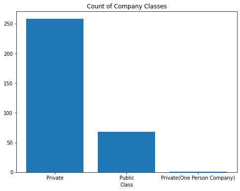

```python
# Plot number of each class
plt.figure(figsize = (8, 6))
plt.bar(table["Class"], table["Count"])
plt.title("Count of Company Classes")
plt.xlabel("Class");
```

### COMPANY_CATEGORY

Category of Company: Limited by Shares, Limited by Guarantee, Unlimited Company.

```python
column = Daman_Diu_2016["COMPANY_CATEGORY"]
column
```

```
0      Company limited by Shares
1      Company limited by Shares
2      Company limited by Shares
3      Company limited by Shares
4      Company limited by Shares
                 ...
322    Company limited by Shares
323    Company limited by Shares
324    Company limited by Shares
325    Company limited by Shares
326    Company limited by Shares
Name: COMPANY_CATEGORY, Length: 327, dtype: object
```

```python
print("Unique values:", column.unique())
print("No. of unique values:", len(column.unique()))

# Number of empty strings
print("Empty strings:", sum(column == " "))

# Table of number of each category
table = column.value_counts().rename_axis('Category').reset_index(name='Count')
table
```

```
Unique values: ['Company limited by Shares' 'Company Limited by Guarantee']
No. of unique values: 2
Empty strings: 0
```

|  | Category | Count |
| --- | --- | --- |
| 0 | Company limited by Shares | 325 |
| 1 | Company Limited by Guarantee | 2 |

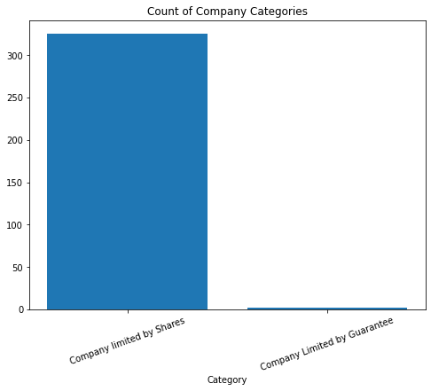

```python
# Plot number of each Category
plt.figure(figsize = (8, 6))
plt.bar(table["Category"], table["Count"])
plt.title("Count of Company Categories")
plt.xlabel("Category")
plt.xticks(rotation = 20);
```

### COMPANY_SUBCAT

Subcategory of Company: Non-govt, Union Gtvt, State Govt, Subsidiary of Foreign Company, Guarantee and Association Company.

```python
column = Daman_Diu_2016["COMPANY_SUBCAT"]
column
```

```
0      Non-govt company
1      Non-govt company
2      Non-govt company
3      Non-govt company
4      Non-govt company
             ...
322    Non-govt company
323    Non-govt company
324    Non-govt company
325    Non-govt company
326    Non-govt company
Name: COMPANY_SUBCAT, Length: 327, dtype: object
```

```python
print("Unique values:", column.unique())
print("No. of unique values:", len(column.unique()))

# Number of empty strings
print("Empty strings:", sum(column == " "))

# Table of number of each sub-category
table = column.value_counts().rename_axis('Sub-category').reset_index(name='Count')
table
```

```
Unique values: ['Non-govt company' 'State Govt company' 'Guarantee and Association comp']
No. of unique values: 3
Empty strings: 0
```

|  | Sub-category | Count |
| --- | --- | --- |
| 0 | Non-govt company | 324 |
| 1 | State Govt company | 2 |
| 2 | Guarantee and Association comp | 1 |

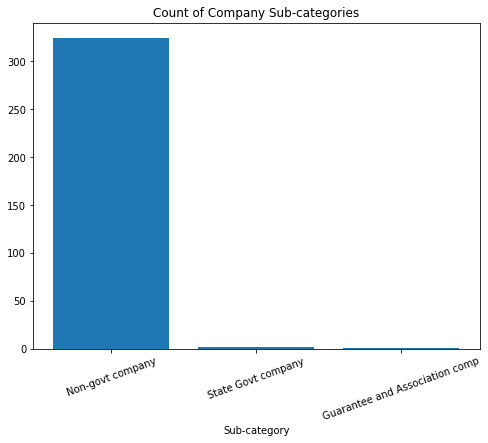

```python
# Plot number of each sub-category
plt.figure(figsize = (8, 6))
plt.bar(table["Sub-category"], table["Count"])
plt.title("Count of Company Sub-categories")
plt.xlabel("Sub-category")
plt.xticks(rotation = 20);
```

### COMPANY_STATUS

Status of Company.

```python
column = Daman_Diu_2016["COMPANY_STATUS"]
column
```

```
0      ACTIVE
1      ACTIVE
2      ACTIVE
3      ACTIVE
4      ACTIVE
        ...
322    ACTIVE
323    ACTIVE
324    ACTIVE
325    ACTIVE
326    ACTIVE
Name: COMPANY_STATUS, Length: 327, dtype: object
```

```python
print("Unique values:", column.unique())
print("No. of unique values:", len(column.unique()))

# Number of empty strings
print("Empty strings:", sum(column == " "))

# Table of number of each status
counter = dict(Counter(column))
count = { key:[value] for key, value in counter.items()}
table = pd.DataFrame.from_dict(count).rename(columns={" ": "Empty"})
table = table.melt(var_name="Status", value_name="Count")
table
```

```
Unique values: ['ACTIVE' 'STRUCK-OFF' 'UNDER LIQUIDATION' 'UNDER PROCESS OF STRUCK-OFF'
 'INACTIVE UNDER SECTION 455 OF CA,2013' 'CONVERTED TO LLP AND DISSOLVED'
 'AMALGAMATED' 'LIQUIDATED' 'DORMANT UNDER SECTION 455 OF CA,2013']
No. of unique values: 9
Empty strings: 0
```

|  | Status | Count |
| --- | --- | --- |
| 0 | ACTIVE | 214 |
| 1 | STRUCK-OFF | 52 |
| 2 | UNDER LIQUIDATION | 3 |
| 3 | UNDER PROCESS OF STRUCK-OFF | 34 |
| 4 | INACTIVE UNDER SECTION 455 OF CA,2013 | 14 |
| 5 | CONVERTED TO LLP AND DISSOLVED | 2 |
| 6 | AMALGAMATED | 6 |
| 7 | LIQUIDATED | 1 |
| 8 | DORMANT UNDER SECTION 455 OF CA,2013 | 1 |

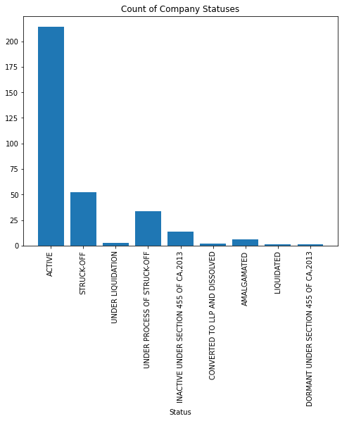

```python
# Plot number of each status
plt.figure(figsize = (8, 6))
plt.bar(table["Status"], table["Count"])
plt.title("Count of Company Statuses")
plt.xlabel("Status")
plt.xticks(rotation = 90);
```

### DATE_OF_REGISTRATION

Timestamp of date of registration.

```python
column = Daman_Diu_2016["DATE_OF_REGISTRATION"]
column
```

```
0      1998-12-11
1      2005-01-31
2      1992-11-18
3      1994-11-22
4      1999-08-09
          ...
322    2012-11-27
323    1983-02-24
324    2009-06-09
325    2011-07-26
326    2010-09-13
Name: DATE_OF_REGISTRATION, Length: 327, dtype: object
```

```python
# Number of null values
print("Null:", sum(column.isnull()))

# Drop null values
cleaned = column.dropna()
# Convert all objects to str in YYYY-MM-DD format
dates = cleaned.astype(str).apply(lambda x: x[:10])

# Range
print("Min:", min(dates))
print("Max:", max(dates))
```

```
Null: 0
Min: 1945-02-07
Max: 2016-10-03
```

```python
years = dates.apply(lambda x: int(x[:4]))
# Table of number of each year
counter = dict(Counter(years))
count = { key:[value] for key, value in counter.items()}
table = pd.DataFrame.from_dict(count)
table = table.melt(var_name="Date", value_name="Count")
print("No. of unique values:", table.shape[0])
table
```

```
No. of unique values: 42
```

|  | Date | Count |
| --- | --- | --- |
| 0 | 1998 | 9 |
| 1 | 2005 | 10 |
| 2 | 1992 | 15 |
| 3 | 1994 | 20 |
| 4 | 1999 | 15 |
| 5 | 2006 | 3 |
| 6 | 2007 | 7 |
| 7 | 1988 | 16 |
| 8 | 2010 | 12 |
| 9 | 2013 | 18 |
| 10 | 2012 | 11 |
| 11 | 2015 | 9 |
| 12 | 2014 | 7 |
| 13 | 2003 | 10 |
| 14 | 2002 | 3 |
| 15 | 1996 | 15 |
| 16 | 1995 | 19 |
| 17 | 2008 | 10 |
| 18 | 1993 | 16 |
| 19 | 2004 | 10 |
| 20 | 2011 | 12 |
| 21 | 2000 | 8 |
| 22 | 2009 | 8 |
| 23 | 1990 | 2 |
| 24 | 1989 | 10 |
| 25 | 1997 | 9 |
| 26 | 1982 | 4 |
| 27 | 1991 | 4 |
| 28 | 1986 | 3 |
| 29 | 1981 | 2 |
| 30 | 1979 | 2 |
| 31 | 1975 | 4 |
| 32 | 1987 | 5 |
| 33 | 2016 | 8 |
| 34 | 1972 | 1 |
| 35 | 1984 | 1 |
| 36 | 1983 | 2 |
| 37 | 1971 | 1 |
| 38 | 1978 | 1 |
| 39 | 1985 | 2 |
| 40 | 2001 | 2 |
| 41 | 1945 | 1 |

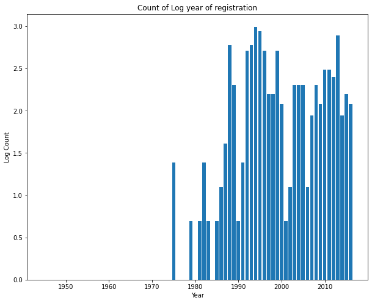

```python
# Plot of number of each year
plt.figure(figsize = (10, 8))
plt.bar(table["Date"], np.log(table["Count"]))
plt.title("Count of Log year of registration")
plt.ylabel("Log Count")
plt.xlabel("Year");
```

### REGISTERED_STATE

State of registration.

```python
column = Daman_Diu_2016["REGISTERED_STATE"]
column
```

```
0      Daman and Diu
1      Daman and Diu
2      Daman and Diu
3      Daman and Diu
4      Daman and Diu
           ...
322    Daman and Diu
323    Daman and Diu
324    Daman and Diu
325    Daman and Diu
326    Daman and Diu
Name: REGISTERED_STATE, Length: 327, dtype: object
```

```python
print("Unique values:", column.unique())
print("No. of unique values:", len(column.unique()))

# Number of empty strings
print("Empty strings:", sum(column == " "))

# Table of number of each state
counter = dict(Counter(column))
count = { key:[value] for key, value in counter.items()}
table = pd.DataFrame.from_dict(count).rename(columns={" ": "Empty"})
table = table.melt(var_name="State", value_name="Count")
table
```

```
Unique values: ['Daman and Diu']
No. of unique values: 1
Empty strings: 0
```

|  | State | Count |
| --- | --- | --- |
| 0 | Daman and Diu | 327 |

### Authorized Capital (Rs.)

Authorized capital in rupees (Rs.). Note that there are two white spaces between Capital and (Rs.) in column title.

```python
column = Daman_Diu_2016["Authorized Capital  (Rs.)"]
column
```

```
0      325000000
1       10000000
2      250000000
3      725000000
4      973500000
         ...
322       100000
323    181000000
324     32500000
325       100000
326      5500000
Name: Authorized Capital  (Rs.), Length: 327, dtype: int64
```

```python
# Number of 0 values
print("0 Capital:", sum(column == 0))
print("No. of unique values:", len(column.unique()))

# Summary Statistics
print("Min:", min(column))
print("Max:", max(column))
print("Mean:", statistics.mean(column))
print("Mode:", statistics.mode(column))
print("Median:", statistics.median(column))
```

```
0 Capital: 1
No. of unique values: 83
Min: 0
Max: 3600000000
Mean: 63307488.318042815
Mode: 100000
Median: 3000000
```

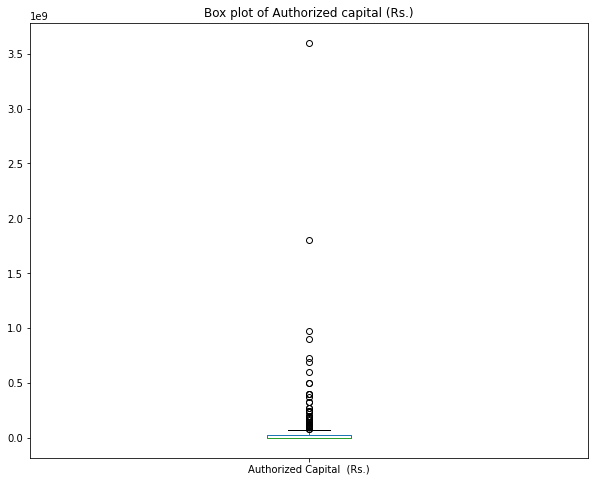

```python
plt.figure(figsize = (10, 8))
column.plot.box()
plt.title("Box plot of Authorized capital (Rs.)")
plt.show()
```

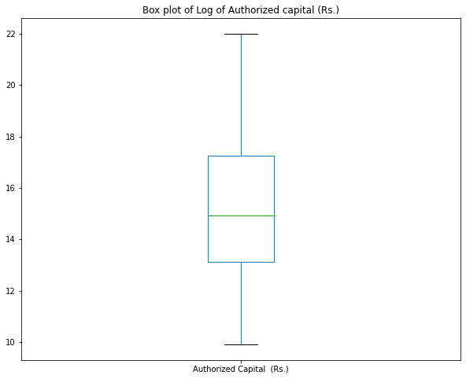

```python
logged = column.apply(lambda x: np.log(x))
plt.figure(figsize = (10, 8))
logged.plot.box()
plt.title("Box plot of Log of Authorized capital (Rs.)")
plt.show()
```

### PAIDUP_CAPITAL (Rs.)

Paid up capital in rupees (Rs.). Note: leading whitespace in column title.

```python
column = Daman_Diu_2016[" PAIDUP_CAPITAL (RS.)"]
column
```

```
0       65806450
1        4700000
2       95014000
3       69425500
4      425988930
         ...
322       100000
323    176000000
324     31250000
325       100000
326      3950000
Name:  PAIDUP_CAPITAL (RS.), Length: 327, dtype: int64
```

```python
# Number of 0 values
print("0 Capital:", sum(column == 0))
print("No. of unique values:", len(column.unique()))

# Summary Statistics
print("Min:", min(column))
print("Max:", max(column))
print("Mean:", statistics.mean(column))
print("Mode:", statistics.mode(column))
print("Median:", statistics.median(column))
```

```
0 Capital: 38
No. of unique values: 168
Min: 0
Max: 3520000000
Mean: 42586023.18348624
Mode: 100000
Median: 500000
```

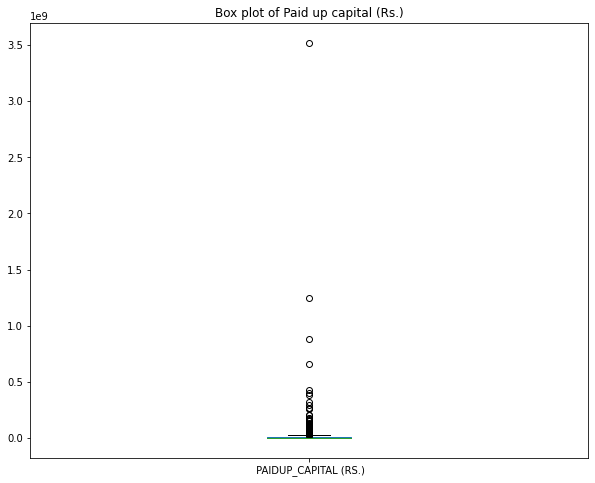

```python
plt.figure(figsize = (10, 8))
column.plot.box()
plt.title("Box plot of Paid up capital (Rs.)")
plt.show()
```

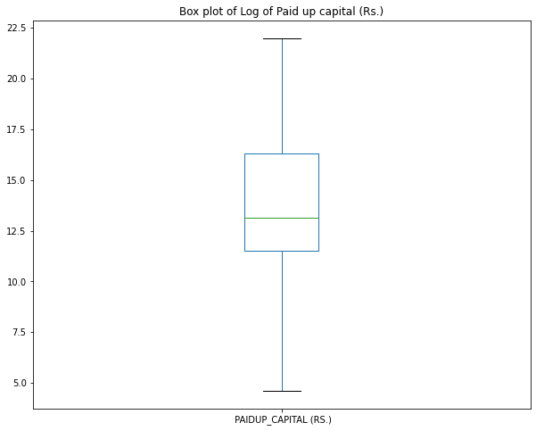

```python
logged = column.apply(lambda x: np.log(x))
plt.figure(figsize = (10, 8))
logged.plot.box()
plt.title("Box plot of Log of Paid up capital (Rs.)")
plt.show()
```

### PRINCIPAL_BUSINESS_ACTIVITY_CODE

Principal Business code that classifies the main type of product/service sold.

```python
column = Daman_Diu_2016["PRINCIPAL_BUSINESS_ACTIVITY_CODE"]
column
```

```
0      31909
1      74110
2      25209
3      65923
4      51900
       ...
322    51101
323    67100
324    93000
325    65992
326    74140
Name: PRINCIPAL_BUSINESS_ACTIVITY_CODE, Length: 327, dtype: int64
```

```python
print("No. of unique values:", len(column.unique()))
print("Min:", min(column))
print("Max:", max(column))

# Table of number of each Principal Business Activity Code
counter = dict(Counter(column))
count = { key:[value] for key, value in counter.items()}
table = pd.DataFrame.from_dict(count).rename(columns={" ": "Empty"})
table = table.melt(var_name="Principal Business Activity Code", value_name="Count").sort_values(by=["Count"], ascending=False).reset_index(drop=True)
table
```

```
No. of unique values: 161
Min: 6
Max: 93000
```

|  | Principal Business Activity Code | Count |
| --- | --- | --- |
| 0 | 25209 | 21 |
| 1 | 67120 | 14 |
| 2 | 74999 | 10 |
| 3 | 55101 | 10 |
| 4 | 51909 | 10 |
| ... | ... | ... |
| 156 | 26103 | 1 |
| 157 | 26104 | 1 |
| 158 | 26931 | 1 |
| 159 | 27101 | 1 |
| 160 | 74140 | 1 |

161 rows × 2 columns

### REGISTERED_OFFICE_ADDRESS

Address of registered office.

```python
column = Daman_Diu_2016["REGISTERED_OFFICE_ADDRESS"]
column
```

```
0                           213,SABARI  KACHGAM IN396210
1      105, PUSHPANAJALI APARTMENTSAI KRUPA SOCIETY, ...
2      363/1(1,2,3), SHREE GANESH INDUSTRIAL ESTATEKA...
3      363/1(1,2,3), SHREE GANESH INDUSTRIAL ESTATEKA...
4      Office No.141, Center Point,Somnath  DamanDama...
                             ...
322    342, CHORO MITHABAVA,GHOGHALA DIU, GHOGHALA  D...
323    Office No.141, Center Point,Somnath  Daman IN3...
324    Flat No. 304, "SAI NIVAS-C"   KathiriaDamanIN3...
325    ABHILASHA COMPLEX, H-NO.15/24/A, SHOP NO.4KHAR...
326    Flat No. 133,Ansal Chamber-II, Bhikaji Cama Pl...
Name: REGISTERED_OFFICE_ADDRESS, Length: 327, dtype: object
```

```python
# Number of invalid addresses
print("Invalid:", sum(column == "      IN"))
# -1 from invalid value
print("No. of unique values:", len(column.unique()) - 1)
```

```
Invalid: 0
No. of unique values: 305
```

```python
# Check for duplicates
counter = dict(Counter(column))
duplicates = { key:[value] for key, value in counter.items() if value > 1}
print("No. of Duplicates:", len(duplicates))

table = pd.DataFrame.from_dict(duplicates)
table = table.melt(var_name="Duplicate Registered Office Addresses", value_name="Count").sort_values(by=["Count"], ascending=False).reset_index(drop=True)
table
```

```
No. of Duplicates: 15
```

|  | Duplicate Registered Office Addresses | Count |
| --- | --- | --- |
| 0 | Office No.141, Center Point,Somnath DamanDama... | 4 |
| 1 | Plot No. 33, Daman Patalia Road,Bhimpore Dama... | 4 |
| 2 | Plot No. 33, Unit-II,Silver Industrial Estate,... | 3 |
| 3 | SHOP NO. 15, SHANTINIKETAN BUILDING,KEVDI FALI... | 3 |
| 4 | 363/1(1,2,3), SHREE GANESH INDUSTRIAL ESTATEKA... | 2 |
| 5 | Office No. 112, 1st Floor, Fortune Gee Bee Com... | 2 |
| 6 | Balasaheb P Daund,Prajapati Complex,Road No.10... | 2 |
| 7 | 105, PUSHPANAJALI APPARTMENT, SAI KRUPA SOCIET... | 2 |
| 8 | PLOT NO. 33, DAMAN PATALIA ROAD,BHIMPORE DAMA... | 2 |
| 9 | PLOT NO. 33, DAMAN PATALIA ROAD,BHIMPORE, DAMA... | 2 |
| 10 | 139ANDRUL INDUSTRIAL ESTATESILVASSA DAMAN IN3... | 2 |
| 11 | A2-4, DAMAN INDUSTRIAL ESTATE,DAMAN. DAMAN. IN0 | 2 |
| 12 | H. NO. 7/5 - 11A, 1ST FLOOR, SHIV SAGAR BUILDI... | 2 |
| 13 | Shop No 9, Somnath Commercial CenterVapi Daman... | 2 |
| 14 | Flat No. 304, "SAI NIVAS-C" KathiriaDamanIN3... | 2 |

```python
Daman_Diu_2016[Daman_Diu_2016["REGISTERED_OFFICE_ADDRESS"].isin(duplicates)].sort_values('REGISTERED_OFFICE_ADDRESS')
```

|  | CIN | COMPANY_NAME | COMPANY_CLASS | COMPANY_CATEGORY | COMPANY_SUBCAT | COMPANY_STATUS | DATE_OF_REGISTRATION | REGISTERED_STATE | Authorized Capital (Rs.) | PAIDUP_CAPITAL (RS.) | PRINCIPAL_BUSINESS_ACTIVITY_CODE | REGISTERED_OFFICE_ADDRESS | EMAIL_ID | LATEST ANNUAL REPORT FILING FY END DATE | LATEST BALANCE SHEET FILING FY END DATE |
| --- | --- | --- | --- | --- | --- | --- | --- | --- | --- | --- | --- | --- | --- | --- | --- |
| 73 | U01122DD2010PTC004681 | DHRUV AGRICULTURES PRIVATE LIMITED | Private | Company limited by Shares | Non-govt company | ACTIVE | 2010-02-01 | Daman and Diu | 100000 | 100000 | 1122 | 105, PUSHPANAJALI APPARTMENT, SAI KRUPA SOCIET... | rmjain@bronze-ingot.com | 2016-03-31 | 2016-03-31 |
| 34 | U45200DD2010PTC004680 | KARNAWAT INFRASTRUCTURES PRIVATE LIMITED | Private | Company limited by Shares | Non-govt company | ACTIVE | 2010-01-28 | Daman and Diu | 100000 | 100000 | 45200 | 105, PUSHPANAJALI APPARTMENT, SAI KRUPA SOCIET... | rmjain@bronze-ingot.com | 2015-03-31 | 2015-03-31 |
| 279 | U67120DD1996PTC002008 | KUNTAL SHAREBROKERS PRIVATE LIMITED | Private | Company limited by Shares | Non-govt company | UNDER PROCESS OF STRUCK-OFF | 1996-01-09 | Daman and Diu | 100000 | 0 | 67120 | 139ANDRUL INDUSTRIAL ESTATESILVASSA DAMAN IN3... |  | 0 | 0 |
| 69 | U52321DD1996PTC002009 | DAYITA MERCANTILE PRIVATE LIMITED | Private | Company limited by Shares | Non-govt company | UNDER PROCESS OF STRUCK-OFF | 1996-01-09 | Daman and Diu | 100000 | 0 | 52321 | 139ANDRUL INDUSTRIAL ESTATESILVASSA DAMAN IN3... |  | 0 | 0 |
| 2 | L25209DD1992PLC009784 | TOKYO PLAST INTERNATIONAL LTD | Public | Company limited by Shares | Non-govt company | ACTIVE | 1992-11-18 | Daman and Diu | 250000000 | 95014000 | 25209 | 363/1(1,2,3), SHREE GANESH INDUSTRIAL ESTATEKA... | parul@tokyoplast.com | 2015-03-31 | 2016-03-31 |
| 3 | L65923DD1994PLC009783 | TOKYO FINANCE LIMITED | Public | Company limited by Shares | Non-govt company | ACTIVE | 1994-11-22 | Daman and Diu | 725000000 | 69425500 | 65923 | 363/1(1,2,3), SHREE GANESH INDUSTRIAL ESTATEKA... | info.tokyofinance@gmail.com | 2015-03-31 | 2016-03-31 |
| 247 | U00329DD1975PLC000243 | REMS AUTO ENGINEERS LIMITED | Public | Company limited by Shares | Non-govt company | UNDER PROCESS OF STRUCK-OFF | 1975-09-06 | Daman and Diu | 1000000 | 0 | 329 | A2-4, DAMAN INDUSTRIAL ESTATE,DAMAN. DAMAN. IN0 |  | 0 | 0 |
| 232 | U00200DD1975PTC000241 | DAMAN AUTO INDUSTRIES PRIVATE LIMITED | Private | Company limited by Shares | Non-govt company | UNDER PROCESS OF STRUCK-OFF | 1975-09-06 | Daman and Diu | 1000000 | 0 | 200 | A2-4, DAMAN INDUSTRIAL ESTATE,DAMAN. DAMAN. IN0 |  | 0 | 0 |
| 310 | U67120DD2000PLC004709 | TOTAL SECURITIES LIMITED | Public | Company limited by Shares | Non-govt company | ACTIVE | 2000-01-11 | Daman and Diu | 100000000 | 48000000 | 67120 | Balasaheb P Daund,Prajapati Complex,Road No.10... | totalsecurities@gmail.com | 2015-03-31 | 2015-03-31 |
| 16 | U51909DD2003PTC004684 | TOTAL COMMODITIES (INDIA) PRIVATELIMITED | Private | Company limited by Shares | Non-govt company | ACTIVE | 2003-09-15 | Daman and Diu | 25000000 | 17400000 | 51909 | Balasaheb P Daund,Prajapati Complex,Road No.10... | totalsecurities@gmail.com | 2015-03-31 | 2015-03-31 |
| 320 | U51909DD2004PTC004752 | TRADEBULLS COMMODITIES BROKING PRIVATELIMITED | Private | Company limited by Shares | Non-govt company | ACTIVE | 2004-05-24 | Daman and Diu | 7500000 | 6666700 | 51909 | Flat No. 304, "SAI NIVAS-C" KathiriaDamanIN3... | compliance@tradebulls.in | 2015-03-31 | 2015-03-31 |
| 324 | U93000DD2009PTC004753 | TRADEBULLS SECURITIES PRIVATE LIMITED | Private | Company limited by Shares | Non-govt company | ACTIVE | 2009-06-09 | Daman and Diu | 32500000 | 31250000 | 93000 | Flat No. 304, "SAI NIVAS-C" KathiriaDamanIN3... | compliance@tradebulls.in | 2015-03-31 | 2015-03-31 |
| 292 | U65991DD2015PTC004763 | CHANDARANA SHARES & STOCKS PRIVATELIMITED | Private | Company limited by Shares | Non-govt company | ACTIVE | 2015-07-20 | Daman and Diu | 1000000 | 100000 | 65991 | H. NO. 7/5 - 11A, 1ST FLOOR, SHIV SAGAR BUILDI... | csspl@chandaranaonline.net | 2016-03-31 | 2016-03-31 |
| 287 | U65999DD2015PTC004769 | CHANDARANA SECURITIES PRIVATE LIMITED | Private | Company limited by Shares | Non-govt company | ACTIVE | 2015-10-21 | Daman and Diu | 100000 | 100000 | 65999 | H. NO. 7/5 - 11A, 1ST FLOOR, SHIV SAGAR BUILDI... | csspl@chandaranaonline.net | 2016-03-31 | 2016-03-31 |
| 5 | U51101DD2006PTC009786 | DIPAN MEHTA COMMODITIES PRIVATE LIMITED | Private | Company limited by Shares | Non-govt company | ACTIVE | 2006-08-25 | Daman and Diu | 700000 | 700000 | 51101 | Office No. 112, 1st Floor, Fortune Gee Bee Com... | dm@elixirequities.com | 2016-03-31 | 2016-03-31 |
| 10 | U67120DD1992PTC004770 | ELIXIR WEALTH MANAGEMENT PRIVATE LIMITED | Private | Company limited by Shares | Non-govt company | ACTIVE | 1992-05-29 | Daman and Diu | 500000 | 100200 | 67120 | Office No. 112, 1st Floor, Fortune Gee Bee Com... | dm@elixirequities.com | 2016-03-31 | 2016-03-31 |
| 6 | U65923DD2007PTC009790 | L. C. RAHEJA FOREX PRIVATE LIMITED | Private | Company limited by Shares | Non-govt company | ACTIVE | 2007-11-15 | Daman and Diu | 10000000 | 9200000 | 65923 | Office No.141, Center Point,Somnath DamanDama... | sandeep.bhanushali@dolatcapital.com | 2015-03-31 | 2015-03-31 |
| 4 | U51900DD1999PTC009780 | CITADELLE AGENCIES PRIVATE LIMITED | Private | Company limited by Shares | Non-govt company | ACTIVE | 1999-08-09 | Daman and Diu | 973500000 | 425988930 | 51900 | Office No.141, Center Point,Somnath DamanDama... | sandeep.bhanushali@dolatcapital.com | 2015-03-31 | 2015-03-31 |
| 309 | U67120DD2001PTC009787 | VAIPAN SECURITIES PRIVATE LIMITED | Private | Company limited by Shares | Non-govt company | ACTIVE | 2001-03-05 | Daman and Diu | 36000000 | 32000000 | 67120 | Office No.141, Center Point,Somnath DamanDama... | sandeep.bhanushali@dolatcapital.com | 2015-03-31 | 2015-03-31 |
| 7 | U65990DD1988PTC009781 | KHYATI INVESTMENTS PRIVATE LIMITED | Private | Company limited by Shares | Non-govt company | ACTIVE | 1988-02-02 | Daman and Diu | 64300000 | 61986250 | 65990 | Office No.141, Center Point,Somnath DamanDama... | sandeep.bhanushali@dolatcapital.com | 2015-03-31 | 2015-03-31 |
| 48 | U40108DD2011PTC004701 | VAAYU RENEWABLE ENERGY (ARABIAN SEA)PRIVATE LI... | Private | Company limited by Shares | Non-govt company | ACTIVE | 2011-10-17 | Daman and Diu | 150000000 | 22600000 | 40108 | PLOT NO. 33, DAMAN PATALIA ROAD,BHIMPORE DAMA... | ipp.compliance@windworldindia.com | 2015-03-31 | 2015-03-31 |
| 54 | U40102DD2009PTC004677 | VAAYU (INDIA) POWER CORPORATION PRIVATELIMITED | Private | Company limited by Shares | Non-govt company | ACTIVE | 2009-11-12 | Daman and Diu | 3600000000 | 3520000000 | 40102 | PLOT NO. 33, DAMAN PATALIA ROAD,BHIMPORE DAMA... | ipp.compliance@windworldindia.com | 2015-03-31 | 2015-03-31 |
| 50 | U40108DD2005PTC004653 | WIND WORLD WIND FARMS (SAI) PRIVATELIMITED | Private | Company limited by Shares | Non-govt company | ACTIVE | 2005-09-23 | Daman and Diu | 160000000 | 160000000 | 40108 | PLOT NO. 33, DAMAN PATALIA ROAD,BHIMPORE, DAMA... | ipp.compliance@windworldindia.com | 2008-03-31 | 2008-03-31 |
| 49 | U40108DD2005PTC004654 | WIND WORLD WIND FARMS (PRITHVI) PRIVATELIMITED | Private | Company limited by Shares | Non-govt company | ACTIVE | 2005-12-30 | Daman and Diu | 65000000 | 65000000 | 40108 | PLOT NO. 33, DAMAN PATALIA ROAD,BHIMPORE, DAMA... | ipp.compliance@windworldindia.com | 2012-03-31 | 2013-03-31 |
| 53 | U40102DD2013PTC004735 | VAAYU RENEWABLE ENERGY (MEVASA) PRIVATELIMITED | Private | Company limited by Shares | Non-govt company | ACTIVE | 2013-10-12 | Daman and Diu | 100000 | 100000 | 40102 | Plot No. 33, Daman Patalia Road,Bhimpore Dama... | ipp.compliance@windworldindia.com | 2015-03-31 | 2015-03-31 |
| 47 | U40108DD2013PTC004718 | VAAYU RENEWABLE ENERGY (KALAKUDI)PRIVATE LIMIT... | Private | Company limited by Shares | Non-govt company | ACTIVE | 2013-05-21 | Daman and Diu | 100000 | 100000 | 40108 | Plot No. 33, Daman Patalia Road,Bhimpore Dama... | ipp.compliance@windworldindia.com | 2015-03-31 | 2015-03-31 |
| 46 | U40108DD2013PTC004723 | VAAYU RENEWABLE ENERGY (VAGAIKULAM)PRIVATE LIM... | Private | Company limited by Shares | Non-govt company | ACTIVE | 2013-07-20 | Daman and Diu | 100000 | 100000 | 40108 | Plot No. 33, Daman Patalia Road,Bhimpore Dama... | ipp.compliance@windworldindia.com | 2015-03-31 | 2015-03-31 |
| 45 | U40108DD2013PTC004734 | VAAYU RENEWABLE ENERGY (MANDVI) PRIVATELIMITED | Private | Company limited by Shares | Non-govt company | ACTIVE | 2013-10-12 | Daman and Diu | 100000 | 100000 | 40108 | Plot No. 33, Daman Patalia Road,Bhimpore Dama... | ipp.compliance@windworldindia.com | 2015-03-31 | 2015-03-31 |
| 39 | U40109DD2013PTC004726 | WIND WORLD WIND FARMS (SANGOLE) PRIVATELIMITED | Private | Company limited by Shares | Non-govt company | ACTIVE | 2013-07-30 | Daman and Diu | 100000 | 100000 | 40109 | Plot No. 33, Unit-II,Silver Industrial Estate,... | legal.compliance@windworldinda.com | 2015-03-31 | 2015-03-31 |
| 38 | U40109DD2013PTC004727 | WIND WORLD WIND FARMS (TAPTI) PRIVATELIMITED | Private | Company limited by Shares | Non-govt company | ACTIVE | 2013-07-30 | Daman and Diu | 100000 | 100000 | 40109 | Plot No. 33, Unit-II,Silver Industrial Estate,... | legal.compliance@windworldinda.com | 2015-03-31 | 2015-03-31 |
| 37 | U40109DD2013PTC004728 | WIND WORLD WIND FARMS (AMBIKA) PRIVATELIMITED | Private | Company limited by Shares | Non-govt company | ACTIVE | 2013-07-30 | Daman and Diu | 100000 | 100000 | 40109 | Plot No. 33, Unit-II,Silver Industrial Estate,... | legal.compliance@windworldinda.com | 2015-03-31 | 2015-03-31 |
| 313 | U74999DD2007PTC004747 | AFFLUENCE COMMODITIES PRIVATE LIMITED | Private | Company limited by Shares | Non-govt company | ACTIVE | 2007-01-30 | Daman and Diu | 30000000 | 7100000 | 74999 | SHOP NO. 15, SHANTINIKETAN BUILDING,KEVDI FALI... | affluence@affluencetrade.com | 2016-03-31 | 2016-03-31 |
| 314 | U67120DD2009PTC004746 | AFFLUENCE FINCON SERVICE PRIVATE LIMITED | Private | Company limited by Shares | Non-govt company | ACTIVE | 2009-05-12 | Daman and Diu | 4500000 | 4000000 | 67120 | SHOP NO. 15, SHANTINIKETAN BUILDING,KEVDI FALI... | affluence@affluencetrade.com | 2016-03-31 | 2016-03-31 |
| 315 | U67120DD2000PTC004748 | AFFLUENCE SHARES AND STOCKS PRIVATELIMITED | Private | Company limited by Shares | Non-govt company | ACTIVE | 2000-01-21 | Daman and Diu | 100000000 | 50000000 | 67120 | SHOP NO. 15, SHANTINIKETAN BUILDING,KEVDI FALI... | affluence@affluencetrade.com | 2016-03-31 | 2016-03-31 |
| 301 | U67190DD2013PTC004721 | QUANT CAPITAL SECURITIES PRIVATE LIMITED | Private | Company limited by Shares | Non-govt company | ACTIVE | 2013-06-27 | Daman and Diu | 270000000 | 270000000 | 67190 | Shop No 9, Somnath Commercial CenterVapi Daman... | secretarial@quantcapital.co.in | 2014-03-31 | 2014-03-31 |
| 305 | U67120DD2013PTC004719 | QCAP SECURITIES PRIVATE LIMITED | Private | Company limited by Shares | Non-govt company | ACTIVE | 2013-06-11 | Daman and Diu | 270000000 | 270000000 | 67120 | Shop No 9, Somnath Commercial CenterVapi Daman... | secretarial@quantcapital.co.in | 2014-03-31 | 2014-03-31 |

Duplicates in `REGISTERED_OFFICE_ADDRESS` do not mean duplicates in companies. Sometimes a very small NGO cannot afford their own office, and will register their non-profit under another existing one. Also, some companies that share an address are branches of the same company.

### EMAIL_ID

Company email.

```python
column = Daman_Diu_2016["EMAIL_ID"]
column
```

```
0               darshanvoraandco@gmail.com
1                   jaindeepak13@gmail.com
2                     parul@tokyoplast.com
3              info.tokyofinance@gmail.com
4      sandeep.bhanushali@dolatcapital.com
                      ...
322                viprittrading@yahoo.com
323    sandeep.bhanushali@dolatcapital.com
324               compliance@tradebulls.in
325                   cakartik85@gmail.com
326                 mkc_ca@youbroadband.in
Name: EMAIL_ID, Length: 327, dtype: object
```

```python
# Number of empty strings
print("Empty strings:", sum(column == " "))
# -1 from invalid value
print("No. of unique values:", len(column.unique()) - 1)

# Check for duplicates
counter = dict(Counter(column))
duplicates = { key:[value] for key, value in counter.items() if value > 1}
# Remove empty string duplicates
del duplicates[" "]
print("No. of Duplicates:", len(duplicates))

table = pd.DataFrame.from_dict(duplicates)
table = table.melt(var_name="Duplicate Email IDs", value_name="Count").sort_values(by=["Count"], ascending=False).reset_index(drop=True)
table
```

```
Empty strings: 87
No. of unique values: 180
No. of Duplicates: 30
```

|  | Duplicate Email IDs | Count |
| --- | --- | --- |
| 0 | ipp.compliance@windworldindia.com | 13 |
| 1 | sandeep.bhanushali@dolatcapital.com | 8 |
| 2 | jyotsna.solse@cellopens.com | 5 |
| 3 | legal.compliance@windworldinda.com | 5 |
| 4 | khemani_ad1@sancharnet.in | 4 |
| 5 | accounts@satec.co.in | 3 |
| 6 | affluence@affluencetrade.com | 3 |
| 7 | legal.compliance@windworldindia.com | 3 |
| 8 | alliedplastics@vsnl.com | 3 |
| 9 | vyas4you@gmail.com | 3 |
| 10 | nissans@vsnl.com | 2 |
| 11 | secretarial@quantcapital.co.in | 2 |
| 12 | csspl@chandaranaonline.net | 2 |
| 13 | sandeepbhanushali@dolatcapital.com | 2 |
| 14 | yatin@vijetabroking.com | 2 |
| 15 | ln1957@rediffmail.com | 2 |
| 16 | psllegal@pslltd.co.in | 2 |
| 17 | rmcl@rmclindia.co.in | 2 |
| 18 | j.vishal27@gmail.com | 2 |
| 19 | prr@princemultiplast.com | 2 |
| 20 | fiberweb@vsnl.net | 2 |
| 21 | dm@elixirequities.com | 2 |
| 22 | ttl@timetechnoplast.com | 2 |
| 23 | bhatia@shingarlimited.com | 2 |
| 24 | rkchandgothia@gmail.com | 2 |
| 25 | totalsecurities@gmail.com | 2 |
| 26 | metallink@bronze-ingot.com | 2 |
| 27 | rmjain@bronze-ingot.com | 2 |
| 28 | dimpi.vyas@indiaadvantage.co.in | 2 |
| 29 | compliance@tradebulls.in | 2 |

```python
Daman_Diu_2016[Daman_Diu_2016['EMAIL_ID'] == 'ipp.compliance@windworldindia.com']
```

|  | CIN | COMPANY_NAME | COMPANY_CLASS | COMPANY_CATEGORY | COMPANY_SUBCAT | COMPANY_STATUS | DATE_OF_REGISTRATION | REGISTERED_STATE | Authorized Capital (Rs.) | PAIDUP_CAPITAL (RS.) | PRINCIPAL_BUSINESS_ACTIVITY_CODE | REGISTERED_OFFICE_ADDRESS | EMAIL_ID | LATEST ANNUAL REPORT FILING FY END DATE | LATEST BALANCE SHEET FILING FY END DATE |
| --- | --- | --- | --- | --- | --- | --- | --- | --- | --- | --- | --- | --- | --- | --- | --- |
| 36 | U40200DD2013PTC004737 | VAAYU RENEWABLE ENERGY (KOLAM) PRIVATELIMITED | Private | Company limited by Shares | Non-govt company | ACTIVE | 2013-10-12 | Daman and Diu | 100000 | 100000 | 40200 | Plot No. 33, Unit-II, Silver Industrial Estate... | ipp.compliance@windworldindia.com | 2015-03-31 | 2015-03-31 |
| 44 | U40108DD2013PTC004736 | VAAYU RENEWABLE ENERGY (PARNER) PRIVATELIMITED | Private | Company limited by Shares | Non-govt company | ACTIVE | 2013-10-12 | Daman and Diu | 100000 | 100000 | 40108 | Plot No. 33, Daman Patalia Road,Bhimpore Dama... | ipp.compliance@windworldindia.com | 2015-03-31 | 2015-03-31 |
| 45 | U40108DD2013PTC004734 | VAAYU RENEWABLE ENERGY (MANDVI) PRIVATELIMITED | Private | Company limited by Shares | Non-govt company | ACTIVE | 2013-10-12 | Daman and Diu | 100000 | 100000 | 40108 | Plot No. 33, Daman Patalia Road,Bhimpore Dama... | ipp.compliance@windworldindia.com | 2015-03-31 | 2015-03-31 |
| 46 | U40108DD2013PTC004723 | VAAYU RENEWABLE ENERGY (VAGAIKULAM)PRIVATE LIM... | Private | Company limited by Shares | Non-govt company | ACTIVE | 2013-07-20 | Daman and Diu | 100000 | 100000 | 40108 | Plot No. 33, Daman Patalia Road,Bhimpore Dama... | ipp.compliance@windworldindia.com | 2015-03-31 | 2015-03-31 |
| 47 | U40108DD2013PTC004718 | VAAYU RENEWABLE ENERGY (KALAKUDI)PRIVATE LIMIT... | Private | Company limited by Shares | Non-govt company | ACTIVE | 2013-05-21 | Daman and Diu | 100000 | 100000 | 40108 | Plot No. 33, Daman Patalia Road,Bhimpore Dama... | ipp.compliance@windworldindia.com | 2015-03-31 | 2015-03-31 |
| 48 | U40108DD2011PTC004701 | VAAYU RENEWABLE ENERGY (ARABIAN SEA)PRIVATE LI... | Private | Company limited by Shares | Non-govt company | ACTIVE | 2011-10-17 | Daman and Diu | 150000000 | 22600000 | 40108 | PLOT NO. 33, DAMAN PATALIA ROAD,BHIMPORE DAMA... | ipp.compliance@windworldindia.com | 2015-03-31 | 2015-03-31 |
| 49 | U40108DD2005PTC004654 | WIND WORLD WIND FARMS (PRITHVI) PRIVATELIMITED | Private | Company limited by Shares | Non-govt company | ACTIVE | 2005-12-30 | Daman and Diu | 65000000 | 65000000 | 40108 | PLOT NO. 33, DAMAN PATALIA ROAD,BHIMPORE, DAMA... | ipp.compliance@windworldindia.com | 2012-03-31 | 2013-03-31 |
| 50 | U40108DD2005PTC004653 | WIND WORLD WIND FARMS (SAI) PRIVATELIMITED | Private | Company limited by Shares | Non-govt company | ACTIVE | 2005-09-23 | Daman and Diu | 160000000 | 160000000 | 40108 | PLOT NO. 33, DAMAN PATALIA ROAD,BHIMPORE, DAMA... | ipp.compliance@windworldindia.com | 2008-03-31 | 2008-03-31 |
| 52 | U40108DD2000PLC002842 | WIND WORLD WIND FARMS (KARNATAKA)LIMITED | Public | Company limited by Shares | Non-govt company | ACTIVE | 2000-04-05 | Daman and Diu | 400000000 | 400000000 | 40108 | PLOT NO.33,DAMAN PATALIA ROADBHIMPORE, DAMAN ... | ipp.compliance@windworldindia.com | 0 | 2008-03-31 |
| 53 | U40102DD2013PTC004735 | VAAYU RENEWABLE ENERGY (MEVASA) PRIVATELIMITED | Private | Company limited by Shares | Non-govt company | ACTIVE | 2013-10-12 | Daman and Diu | 100000 | 100000 | 40102 | Plot No. 33, Daman Patalia Road,Bhimpore Dama... | ipp.compliance@windworldindia.com | 2015-03-31 | 2015-03-31 |
| 54 | U40102DD2009PTC004677 | VAAYU (INDIA) POWER CORPORATION PRIVATELIMITED | Private | Company limited by Shares | Non-govt company | ACTIVE | 2009-11-12 | Daman and Diu | 3600000000 | 3520000000 | 40102 | PLOT NO. 33, DAMAN PATALIA ROAD,BHIMPORE DAMA... | ipp.compliance@windworldindia.com | 2015-03-31 | 2015-03-31 |
| 55 | U40100DD2000PTC004655 | WIND WORLD WIND FARMS (MAHARANA PRATAP)PRIVATE... | Private | Company limited by Shares | Non-govt company | ACTIVE | 2000-03-03 | Daman and Diu | 100000 | 100000 | 40100 | 33, DAMAN PATALIA ROAD,BHIMPORE, DAMAN DAMAND... | ipp.compliance@windworldindia.com | 2013-03-31 | 2013-03-31 |
| 81 | U00432DD2006PTC004406 | WIND WORLD WIND FARMS (NETTUR) PRIVATELIMITED | Private | Company limited by Shares | Non-govt company | ACTIVE | 2006-02-07 | Daman and Diu | 75000000 | 69000000 | 432 | PLOT NO. 33, DAMAN PATALIAROAD, BHIMPORE,DAMAN... | ipp.compliance@windworldindia.com | 2012-03-31 | 2013-03-31 |

Many of the duplicates in `EMAIL_ID` are branches of the same company.

### LATEST ANNUAL REPORT FILING FY END DATE

Latest annual report filing fiscal year end date.

```python
column = Daman_Diu_2016["LATEST ANNUAL REPORT FILING FY END DATE"]
column
```

```
0      2015-03-31
1      2015-03-31
2      2015-03-31
3      2015-03-31
4      2015-03-31
          ...
322    2016-03-31
323    2015-03-31
324    2015-03-31
325    2016-03-31
326    2012-03-31
Name: LATEST ANNUAL REPORT FILING FY END DATE, Length: 327, dtype: object
```

```python
# Number of invalid values
print("Invalid:", (sum(column == "         0") + sum(column == 0)))
# -1 from invalid value
print("No. of unique values:", len(column.unique()) - 1)

# Count of Latest Annual report filing FY end date
counter = dict(Counter(column))
count = { key:[value] for key, value in counter.items()}
# Remove invalid date duplicates
del count["         0"]

print("Max:", max(count))
print("Min:", min(count))

table = pd.DataFrame.from_dict(count)
table = table.melt(var_name="Count of Latest Annual report filing FY end date", value_name="Count").sort_values(by=["Count"], ascending=False).reset_index(drop=True)
table
```

```
Invalid: 124
No. of unique values: 11
Max: 2016-03-31
Min: 2008-03-31
```

|  | Count of Latest Annual report filing FY end date | Count |
| --- | --- | --- |
| 0 | 2015-03-31 | 121 |
| 1 | 2016-03-31 | 41 |
| 2 | 2014-03-31 | 14 |
| 3 | 2013-03-31 | 10 |
| 4 | 2012-03-31 | 5 |
| 5 | 2009-03-31 | 5 |
| 6 | 2008-03-31 | 2 |
| 7 | 2010-03-31 | 2 |
| 8 | 2014-12-31 | 1 |
| 9 | 2011-03-31 | 1 |
| 10 | 2015-12-31 | 1 |

### LATEST BALANCE SHEET FILING FY END DATE

Latest balance sheet filing fiscal year end date.

```python
column = Daman_Diu_2016["LATEST BALANCE SHEET FILING FY END DATE"]
column
```

```
0      2015-03-31
1      2016-03-31
2      2016-03-31
3      2016-03-31
4      2015-03-31
          ...
322    2016-03-31
323    2015-03-31
324    2015-03-31
325    2016-03-31
326    2013-03-31
Name: LATEST BALANCE SHEET FILING FY END DATE, Length: 327, dtype: object
```

```python
# Number of invalid values
print("Invalid:", (sum(column == "         0") + sum(column == 0)))
# -1 from invalid value
print("No. of unique values:", len(column.unique()) - 1)

# Count of Latest Annual report filing FY end date
counter = dict(Counter(column))
count = { key:[value] for key, value in counter.items()}
# Remove invalid date duplicates
del count["         0"]

print("Max:", max(count))
print("Min:", min(count))

table = pd.DataFrame.from_dict(count)
table = table.melt(var_name="Count of Latest Annual report filing FY end date", value_name="Count").sort_values(by=["Count"], ascending=False).reset_index(drop=True)
table
```

```
Invalid: 133
No. of unique values: 10
Max: 2016-03-31
Min: 2006-03-31
```

|  | Count of Latest Annual report filing FY end date | Count |
| --- | --- | --- |
| 0 | 2015-03-31 | 100 |
| 1 | 2016-03-31 | 67 |
| 2 | 2013-03-31 | 9 |
| 3 | 2014-03-31 | 7 |
| 4 | 2008-03-31 | 5 |
| 5 | 2014-12-31 | 2 |
| 6 | 2011-03-31 | 1 |
| 7 | 2010-03-31 | 1 |
| 8 | 2012-03-31 | 1 |
| 9 | 2006-03-31 | 1 |